# IS606: PROJECT 1

MUSA T. GANIYU

February 27, 2016

**WHAT IMPACT DOES BODY WEIGHT HAVE ON BRAIN WEIGHT?**

**The data records the average weight of the brain and body for a number of mammal species.** **There are 62 rows of data. The 3 data columns include:** **I, the index, A1, the brain weight;** **B, the body weight.** **We seek a model of the form:** **B = A1 * X1.**

**Load data from URL**

```r
require(knitr);
weights <- read.table("http://people.sc.fsu.edu/~jburkardt/datasets/regression/x01.txt", skip = 32, header = TRUE, sep = "")
kable(head(weights));
```

| Body | Weight |
| --- | --- |
| 3.385 | 44.5 |
| 0.480 | 15.5 |
| 1.350 | 8.1 |
| 465.000 | 423.0 |
| 36.330 | 119.5 |
| 27.660 | 115.0 |

```r
names(weights);
```

```
## [1] "Body"   "Weight"
```

```r
options(warn=-1)
```

** Load require package.**

```r
library(plyr);
```

**Note the data columns came with Body & Weight, but its actually “BrainWeight &”BodyWeight" in the data, which needs correction.**

```r
names(weights)[names(weights)=="Body"] <- "BrainWeight";
names(weights)[names(weights)=="Weight"] <- "BodyWeight";
str(weights);
```

```
## 'data.frame':    62 obs. of  2 variables:
##  $ BrainWeight: num  3.38 0.48 1.35 465 36.33 ...
##  $ BodyWeight : num  44.5 15.5 8.1 423 119.5 ...
```

```r
names(weights);
```

```
## [1] "BrainWeight" "BodyWeight"
```

```r
kable(head(weights));
```

| BrainWeight | BodyWeight |
| --- | --- |
| 3.385 | 44.5 |
| 0.480 | 15.5 |
| 1.350 | 8.1 |
| 465.000 | 423.0 |
| 36.330 | 119.5 |
| 27.660 | 115.0 |

**Lets checkout its histogram.**

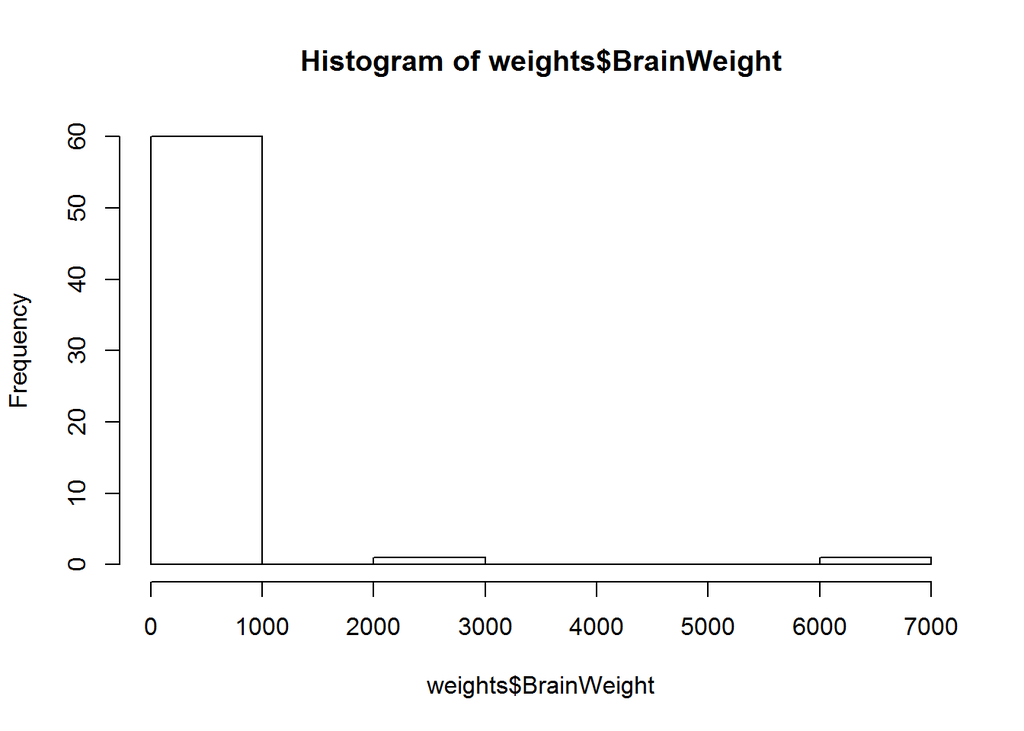

```r
hist(weights$BrainWeight);
```

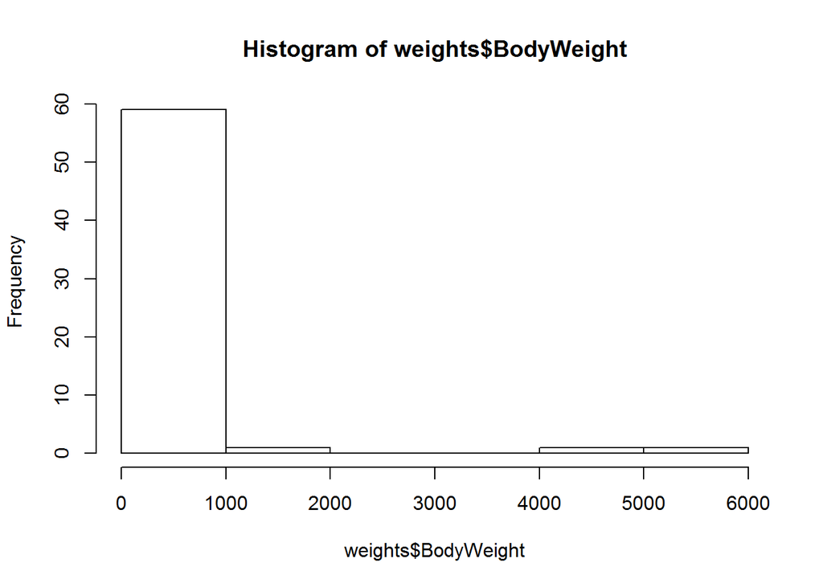

```r
hist(weights$BodyWeight);
```

**We can deduce that it a Very Rightly Skewed data, an intervention is required.Its getting the Natural logarithm of the data set.**

```r
weights_log <- cbind(weights, log(weights$BrainWeight), log(weights$BodyWeight));

kable(head(weights_log));
```

| BrainWeight | BodyWeight | log(weights$BrainWeight) | log(weights$BodyWeight) |
| --- | --- | --- | --- |
| 3.385 | 44.5 | 1.2193539 | 3.795489 |
| 0.480 | 15.5 | -0.7339692 | 2.740840 |
| 1.350 | 8.1 | 0.3001046 | 2.091864 |
| 465.000 | 423.0 | 6.1420374 | 6.047372 |
| 36.330 | 119.5 | 3.5926438 | 4.783316 |
| 27.660 | 115.0 | 3.3199873 | 4.744932 |

**load required package and attach the data again and plot it in scatterplot 3D.**

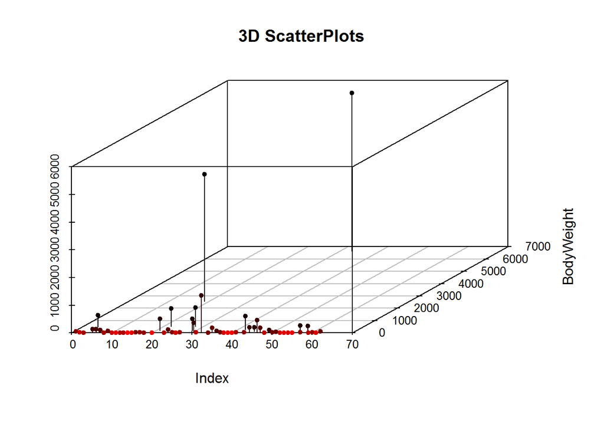

```r
library(scatterplot3d);

attach(weights_log);
scatterplot3d(BrainWeight, BodyWeight, pch = 20, highlight.3d = TRUE, type = "h", main = "3D ScatterPlots");
```

**Removing or seperating new column from initial data set.**

```r
weights_log[,c("BrainWeight","BodyWeight")] <- list(NULL);
colnames(weights_log);
```

```
## [1] "log(weights$BrainWeight)" "log(weights$BodyWeight)"
```

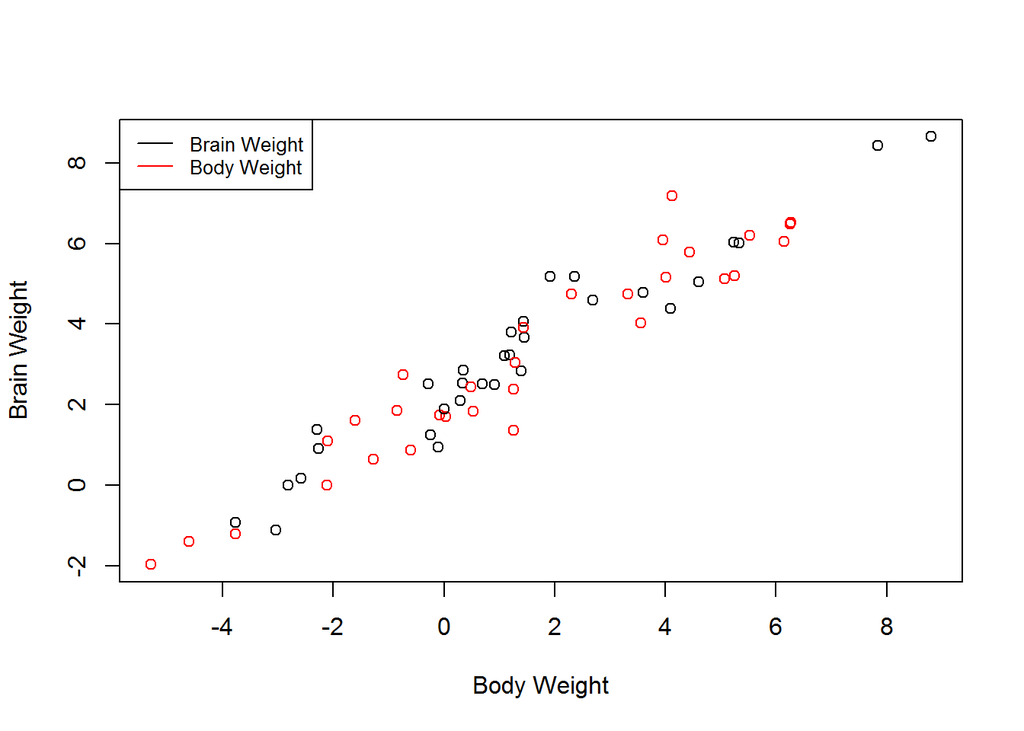

```r
a <- plot(weights_log, ylab="Brain Weight",
   plot.type="double", col=1:2, xlab="Body Weight")
legend("topleft", legend=c("Brain Weight","Body Weight"),
  lty=1, col=c(1,2), cex=.8)
abline(a)
```

**Changing the column name.**

```r
names(weights_log)[names(weights_log)=="log(weights$BrainWeight)"] <- "BrainWeights";
names(weights_log)[names(weights_log)=="log(weights$BodyWeight)"] <- "BodyWeight";

kable(head(weights_log));
```

| BrainWeights | BodyWeight |
| --- | --- |
| 1.2193539 | 3.795489 |
| -0.7339692 | 2.740840 |
| 0.3001046 | 2.091864 |
| 6.1420374 | 6.047372 |
| 3.5926438 | 4.783316 |
| 3.3199873 | 4.744932 |

```r
cor(weights_log, use="complete.obs", method="kendall")
```

```
##              BrainWeights BodyWeight
## BrainWeights    1.0000000  0.8334657
## BodyWeight      0.8334657  1.0000000
```

**Histogram for Body weight**

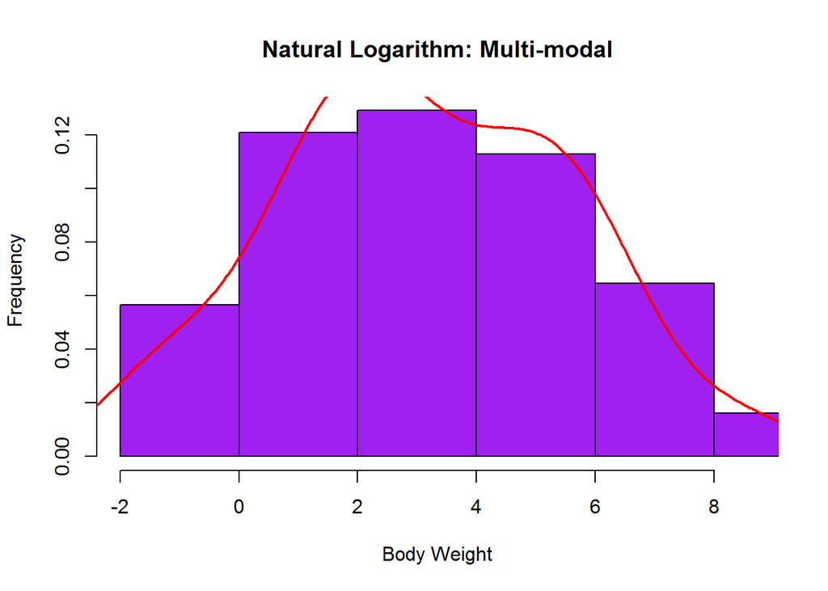

```r
x <- weights_log$BodyWeight;

hist(x,
 xlim=c(min(x),max(x)), probability=T,
   col='purple', xlab='Body Weight', ylab=' Frequency', axes=T,
   main='Natural Logarithm: Multi-modal')
lines(density(x,bw=1), col='red', lwd=2)
```

**Getting the mode of BodyWeight**

```r
mode_1 <- table(as.vector(x));
names(mode_1)[mode_1 == max(mode_1)];
```

```
## [1] "0"                "2.50959926237837" "4.74493212836325"
```

**Histogram for Brain weight**

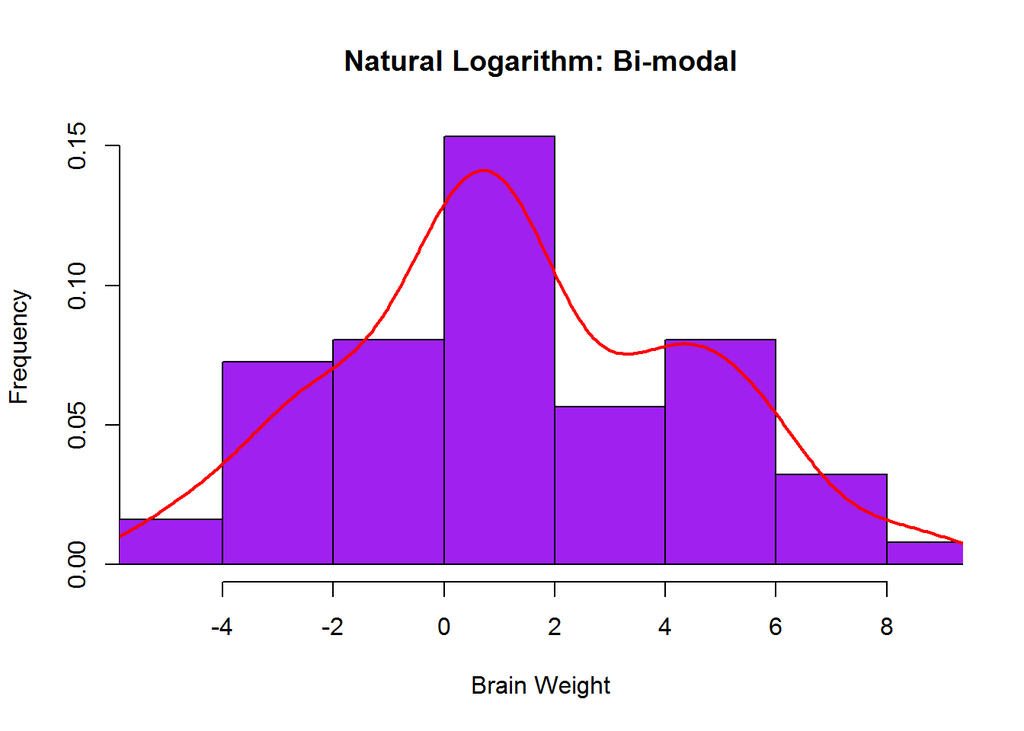

```r
y <- weights_log$BrainWeight;

hist(y,
 xlim=c(min(y),max(y)), probability=T,
   col='purple', xlab='Brain Weight', ylab=' Frequency', axes=T,
   main='Natural Logarithm: Bi-modal')
lines(density(y,bw=1), col='red', lwd=2)
```

```r
kable(summary(weights_log));
```

|  | BrainWeights | BodyWeight |
| --- | --- | --- |
|  | Min. :-5.2983 | Min. :-1.966 |
|  | 1st Qu.:-0.5203 | 1st Qu.: 1.442 |
|  | Median : 1.2066 | Median : 2.848 |
|  | Mean : 1.3375 | Mean : 3.140 |
|  | 3rd Qu.: 3.8639 | 3rd Qu.: 5.111 |
|  | Max. : 8.8030 | Max. : 8.650 |

**Getting the mode of Brain Weight**

```r
mode_2 <- table(as.vector(y));
names(mode_2)[mode_2 == max(mode_2)];
```

```
## [1] "-3.77226106305299" "1.25276296849537"
```

**Load required package forecast, for forecasting.**

```r
library(forecast);
```

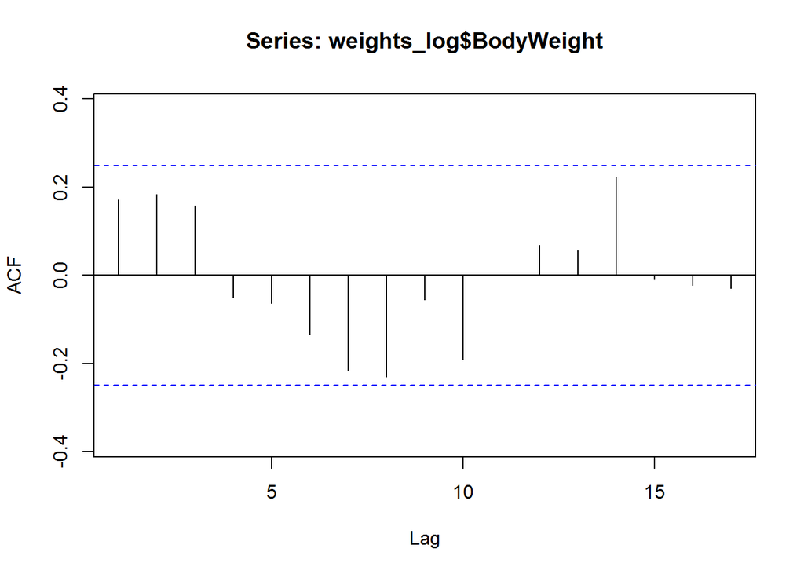

```r
Acf(weights_log$BodyWeight, lag.max=NULL, type=c("correlation", "partial"), plot=TRUE, main=NULL, xlim=NULL, ylim=NULL, xlab="Lag", ylab=NULL, na.action=na.contiguous);
```

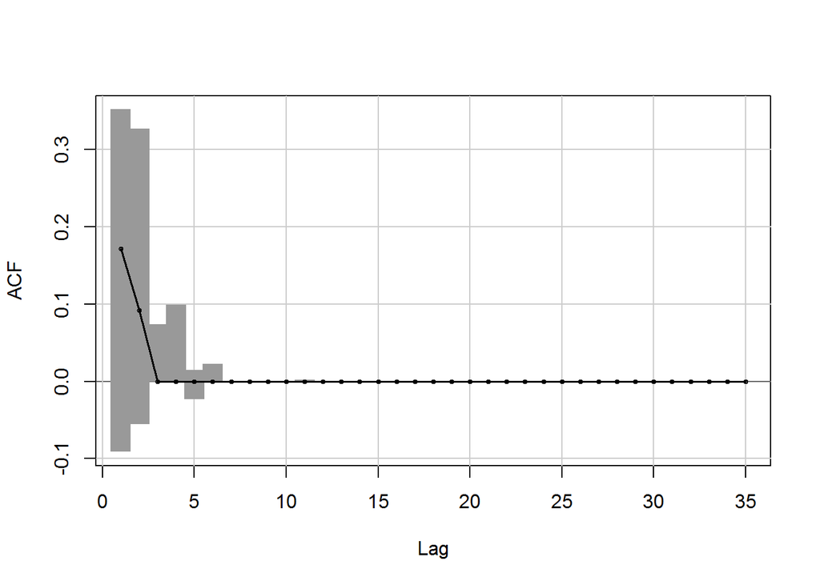

```r
taperedacf(weights_log$BodyWeight, lag.max=NULL, type=c("correlation", "partial"), plot=TRUE, calc.ci=TRUE, level=95, nsim=100, xlim=NULL, ylim=NULL, xlab="Lag", ylab=NULL);
```

```r
fcast <- forecast(weights_log$BodyWeight, h = ifelse(frequency(weights_log$BodyWeight) > 1, 2 * frequency(weights_log$BodyWeight), 10) , level=c(68, 95, 99.7), fan=FALSE, robust=FALSE, lambda=NULL, find.frequency=FALSE, allow.multiplicative.trend=FALSE);

fcast;
```

```
##    Point Forecast     Lo 68    Hi 68     Lo 95    Hi 95   Lo 99.7  Hi 99.7
## 63        3.14003 0.7266564 5.553403 -1.616456 7.896516 -4.062145 10.34220
## 64        3.14003 0.7266564 5.553403 -1.616456 7.896516 -4.062145 10.34220
## 65        3.14003 0.7266564 5.553403 -1.616456 7.896516 -4.062145 10.34221
## 66        3.14003 0.7266564 5.553403 -1.616456 7.896516 -4.062145 10.34221
## 67        3.14003 0.7266564 5.553403 -1.616456 7.896516 -4.062145 10.34221
## 68        3.14003 0.7266564 5.553403 -1.616456 7.896516 -4.062145 10.34221
## 69        3.14003 0.7266564 5.553403 -1.616456 7.896516 -4.062145 10.34221
## 70        3.14003 0.7266564 5.553403 -1.616456 7.896516 -4.062145 10.34221
## 71        3.14003 0.7266563 5.553403 -1.616456 7.896516 -4.062146 10.34221
## 72        3.14003 0.7266563 5.553403 -1.616456 7.896516 -4.062146 10.34221
```

**DATA SOURCE: http://people.sc.fsu.edu/~jburkardt/datasets/regression/x01.txt**

**References:**

**http://r.789695.n4.nabble.com/converting-character-to-numeric-td3615259.html**

**http://stackoverflow.com/questions/4605206/drop-data-frame-columns-by-name**

**https://cran.r-project.org/web/packages/forecast/forecast.pdf**